# Practical Machine Learning Course Project

Jiahe Yu

September 30, 2016

## 1. Introduction

Using devices such as Jawbone Up, Nike FuelBand, and Fitbit it is now possible to collect a large amount of data about personal activity relatively inexpensively. These type of devices are part of the quantified self movement – a group of enthusiasts who take measurements about themselves regularly to improve their health, to find patterns in their behavior, or because they are tech geeks. One thing that people regularly do is quantify how much of a particular activity they do, but they rarely quantify how well they do it.

In this project, I use data from accelerometers on the belt, forearm, arm, and dumbell of participants. Participants were asked to perform barbell lifts correctly and incorrectly in 5 different ways.

I predict the manner in which people did the exercise. This report presents how I build the model, how I used cross validation, the expected out of sample error, and why I made the choices.

## 2. Load the datasets and packages

The data for this project come from this source: http://groupware.les.inf.puc-rio.br/har[1].

The training data for this project are available here:

https://d396qusza40orc.cloudfront.net/predmachlearn/pml-training.csv

The test data are available here:

https://d396qusza40orc.cloudfront.net/predmachlearn/pml-testing.csv

### 2.1 load the data

```r
download.file(url = "https://d396qusza40orc.cloudfront.net/predmachlearn/pml-training.csv",
              destfile = "training.csv")
download.file(url = "https://d396qusza40orc.cloudfront.net/predmachlearn/pml-testing.csv",
              destfile = "testing.csv")
train <- read.csv("training.csv", na.strings = c("NA", ""))
test <- read.csv("testing.csv", na.strings = c("NA", ""))
```

### 2.2 load the packages that I would use

```r
library(caret)
library(gbm)
```

## 3. Data Preparation

### 3.1 initial look at the data

```r
dim(train)
names(train)
str(train)
head(train, 5) # Results are hidden for the purpose of being concise
```

### 3.2 clean the data

```r
train <- train[, -c(1:7)] # the first seven variables are not useful in the analysis so I delete them
test <- test[, -c(1:7)] # do the same thing for the train data
train <- train[, colSums(is.na(train)) == 0] # delete variables that contain missing values
test <- test[, colSums(is.na(test)) == 0] # do the same thing for the train data
```

### 3.3 partrition the training data

Now we have a clean training dataset with 53 variables and 19622 observations and a clean test dataset with 53 variables and 20 observations. Here I partrition the training data into a sub-training dataset and a sub-test dataset to perform cross-validation.

```r
set.seed(929)
index <- createDataPartition(train$classe, p = 0.7, list = F)
subtrain <- train[index, ]
subtest <- train[-index, ]
```

### 3.4 clean up near zero variance features

```r
nzv <- nearZeroVar(subtrain, saveMetrics = T)
subtrain <- subtrain [nzv$nzv == FALSE] # delete the near zero variance features
subtest <- subtest[nzv$nzv == FALSE] # did the same as for the subtrain data
test <- test[nzv$nzv == FALSE] # did the same as for the subtrain data
```

## 4. Exploratory Data Analysis

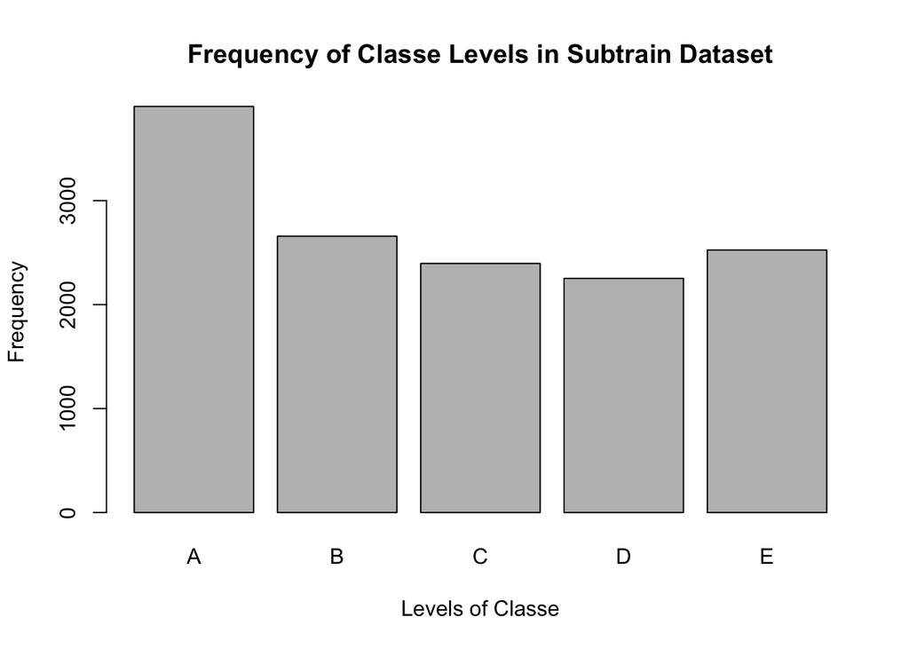

```r
plot(subtrain$classe, xlab = "Levels of Classe", ylab = "Frequency",
     main = "Frequency of Classe Levels in Subtrain Dataset") # Our dependent variable classes has five levels (A, B, C, D, E).
```

```r
summary(subtrain) # check summary statistics of all the variables in the subtrain dataset. The results are hidden for the purpose of being concise
```

## 5. Train Models

### 5.1 Use three different methods to train models

```r
md_rf <- train(classe ~ ., data = subtrain, method = "rf") # use the method of "random forest"
md_gbm <- train(classe ~ ., data = subtrain, method = "gbm") # use the method of "boosting"
md_lda <- train(classe ~ ., data = subtrain, method = "lda") # use "linear discriminant analysis"
```

### 5.2 Model Selection and Out-of-sample Error

```r
pred_rf <- predict(md_rf, subtest)
pred_gbm <- predict(md_gbm, subtest)
pred_lda <- predict(md_lda, subtest)

confusionMatrix(pred_rf, subtest$classe)
```

```
## Confusion Matrix and Statistics
##
##           Reference
## Prediction    A    B    C    D    E
##          A 1674    7    0    0    0
##          B    0 1132    6    0    1
##          C    0    0 1015    7    2
##          D    0    0    5  956    3
##          E    0    0    0    1 1076
##
## Overall Statistics
##
##                Accuracy : 0.9946
##                  95% CI : (0.9923, 0.9963)
##     No Information Rate : 0.2845
##     P-Value [Acc > NIR] : < 2.2e-16
##
##                   Kappa : 0.9931
##  Mcnemar's Test P-Value : NA
##
## Statistics by Class:
##
##                      Class: A Class: B Class: C Class: D Class: E
## Sensitivity            1.0000   0.9939   0.9893   0.9917   0.9945
## Specificity            0.9983   0.9985   0.9981   0.9984   0.9998
## Pos Pred Value         0.9958   0.9939   0.9912   0.9917   0.9991
## Neg Pred Value         1.0000   0.9985   0.9977   0.9984   0.9988
## Prevalence             0.2845   0.1935   0.1743   0.1638   0.1839
## Detection Rate         0.2845   0.1924   0.1725   0.1624   0.1828
## Detection Prevalence   0.2856   0.1935   0.1740   0.1638   0.1830
## Balanced Accuracy      0.9992   0.9962   0.9937   0.9950   0.9971
```

```r
confusionMatrix(pred_gbm, subtest$classe)
```

```
## Confusion Matrix and Statistics
##
##           Reference
## Prediction    A    B    C    D    E
##          A 1648   42    0    0    0
##          B   14 1058   37    3   11
##          C    9   36  969   35    6
##          D    2    3   18  917    7
##          E    1    0    2    9 1058
##
## Overall Statistics
##
##                Accuracy : 0.9601
##                  95% CI : (0.9547, 0.9649)
##     No Information Rate : 0.2845
##     P-Value [Acc > NIR] : < 2.2e-16
##
##                   Kappa : 0.9495
##  Mcnemar's Test P-Value : 2.446e-06
##
## Statistics by Class:
##
##                      Class: A Class: B Class: C Class: D Class: E
## Sensitivity            0.9845   0.9289   0.9444   0.9512   0.9778
## Specificity            0.9900   0.9863   0.9823   0.9939   0.9975
## Pos Pred Value         0.9751   0.9421   0.9185   0.9683   0.9888
## Neg Pred Value         0.9938   0.9830   0.9882   0.9905   0.9950
## Prevalence             0.2845   0.1935   0.1743   0.1638   0.1839
## Detection Rate         0.2800   0.1798   0.1647   0.1558   0.1798
## Detection Prevalence   0.2872   0.1908   0.1793   0.1609   0.1818
## Balanced Accuracy      0.9872   0.9576   0.9634   0.9726   0.9877
```

```r
confusionMatrix(pred_lda, subtest$classe)
```

```
## Confusion Matrix and Statistics
##
##           Reference
## Prediction    A    B    C    D    E
##          A 1377  169   92   55   47
##          B   33  727  104   42  189
##          C  138  151  700  126   94
##          D  118   40  111  696   97
##          E    8   52   19   45  655
##
## Overall Statistics
##
##                Accuracy : 0.706
##                  95% CI : (0.6942, 0.7177)
##     No Information Rate : 0.2845
##     P-Value [Acc > NIR] : < 2.2e-16
##
##                   Kappa : 0.628
##  Mcnemar's Test P-Value : < 2.2e-16
##
## Statistics by Class:
##
##                      Class: A Class: B Class: C Class: D Class: E
## Sensitivity            0.8226   0.6383   0.6823   0.7220   0.6054
## Specificity            0.9138   0.9225   0.8952   0.9256   0.9742
## Pos Pred Value         0.7914   0.6639   0.5790   0.6554   0.8408
## Neg Pred Value         0.9283   0.9140   0.9303   0.9444   0.9164
## Prevalence             0.2845   0.1935   0.1743   0.1638   0.1839
## Detection Rate         0.2340   0.1235   0.1189   0.1183   0.1113
## Detection Prevalence   0.2957   0.1861   0.2054   0.1805   0.1324
## Balanced Accuracy      0.8682   0.7804   0.7888   0.8238   0.7898
```

## 6. Prediction of Classe in Test Data

Based on the random forest model that I chose in the training data, I did final calculations and predict the manner in which people did the exercise in the testing data.

```r
pred_test <- predict(md_rf, test)
print(pred_test) # the answers for the quiz
```

```
##  [1] B A B A A E D B A A B C B A E E A B B B
## Levels: A B C D E
```

## *Reference*

[1] Velloso, E.; Bulling, A.; Gellersen, H.; Ugulino, W.; Fuks, H. Qualitative Activity Recognition of Weight Lifting Exercises. Proceedings of 4th International Conference in Cooperation with SIGCHI (Augmented Human ’13) . Stuttgart, Germany: ACM SIGCHI, 2013.